# Segmentation of Trip Data - Part3

Dave Hurst

Thursday, December 25, 2014

## Investigate Trips with no segments

### A note on the speed plot:

See Part2 for background.

Note … this is starting to get slow, and I can’t get caching to work.

```r
driver.id <- 2591
seg.summary <- data.frame( n.seg=integer(), trip.len=integer(), speed.avg=numeric(), speed.max=numeric(),
                           seg.min=numeric(), seg.max=numeric(), seg.avg=numeric(), seg.sd=numeric())
for(i.trip in 1:200) {
    #cat(i.trip,".")
    trip <- getTrip( driver.id, i.trip, v.thresh=5 )    #v.thresh = default
    ss <- segment.parse.bearing(trip)
    seg.summary[i.trip, ]$trip.len <- nrow(trip)
    seg.summary[i.trip, ]$speed.avg <- mean(trip$v)
    seg.summary[i.trip, ]$speed.max <- max(trip$v)
    seg.summary[i.trip, ]$n.seg   <- nrow(ss)
    if ( nrow(ss) > 0) {
       seg.summary[i.trip, ]$seg.min <- min(ss$tlen)
       seg.summary[i.trip, ]$seg.max <- max(ss$tlen)
       seg.summary[i.trip, ]$seg.avg <- mean(ss$tlen)
       seg.summary[i.trip, ]$seg.sd  <- sd(ss$tlen)
    }
}
print(summary(seg.summary))
```

```
##      n.seg           trip.len        speed.avg         speed.max
##  Min.   : 0.000   Min.   : 156.0   Min.   : 0.1718   Min.   : 1.217
##  1st Qu.: 1.000   1st Qu.: 282.8   1st Qu.: 7.3737   1st Qu.:19.360
##  Median : 2.000   Median : 501.0   Median :12.3487   Median :22.629
##  Mean   : 3.725   Mean   : 636.6   Mean   :11.2350   Mean   :22.706
##  3rd Qu.: 7.000   3rd Qu.: 934.0   3rd Qu.:14.7541   3rd Qu.:25.107
##  Max.   :14.000   Max.   :1634.0   Max.   :21.9898   Max.   :73.715
##
##     seg.min          seg.max         seg.avg           seg.sd
##  Min.   : 30.00   Min.   : 30.0   Min.   : 30.00   Min.   :  0.7071
##  1st Qu.: 34.00   1st Qu.: 63.0   1st Qu.: 56.21   1st Qu.: 18.4210
##  Median : 41.00   Median :108.0   Median : 72.50   Median : 26.8779
##  Mean   : 72.61   Mean   :128.3   Mean   : 95.59   Mean   : 38.6382
##  3rd Qu.: 68.00   3rd Qu.:202.5   3rd Qu.:111.43   3rd Qu.: 53.0330
##  Max.   :276.00   Max.   :324.0   Max.   :276.00   Max.   :164.0488
##  NA's   :25       NA's   :25      NA's   :25       NA's   :91
```

```r
seg0 <- which(seg.summary$n.seg == 0)
seg0
```

```
##  [1]   6  16  40  45  46  60  72  79  82 104 115 122 123 131 133 147 152
## [18] 153 154 155 157 163 187 196 198
```

### Trips with 0 segs

Here’s an example of the plots for these:

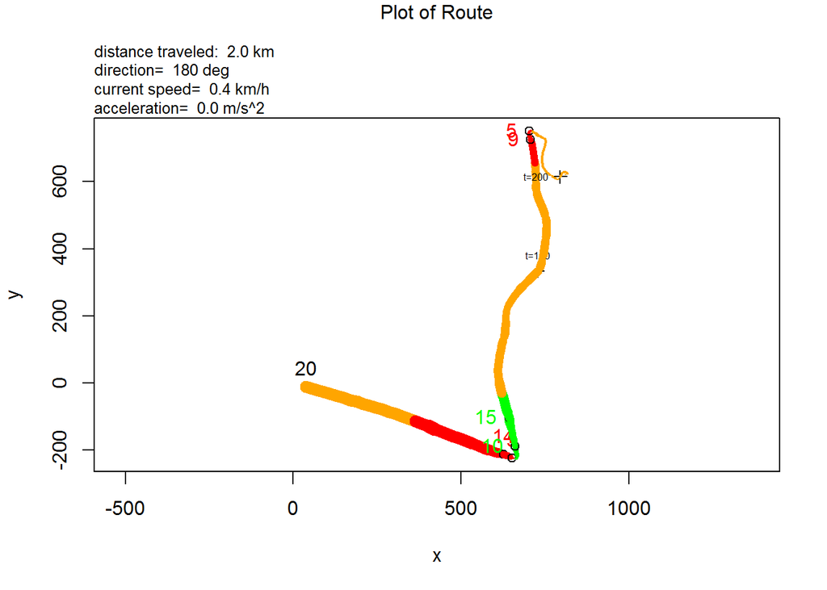

```r
trip.id <- 16
trip <- getTrip( driver.id, trip.id )
plotTrip(trip)
```

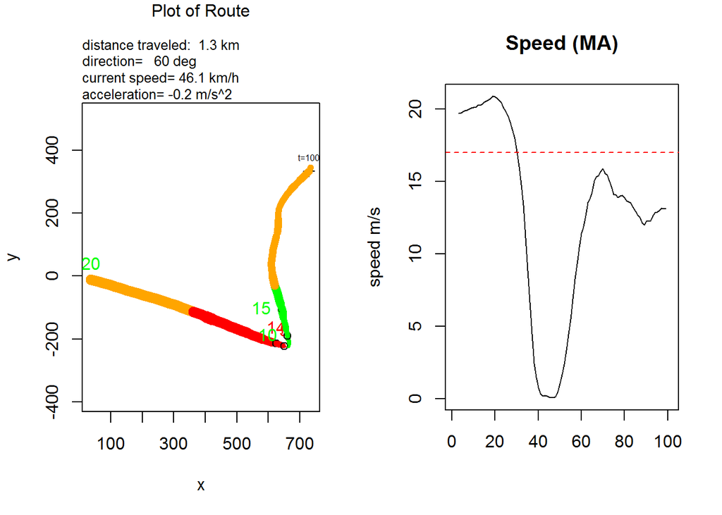

```r
plotTripSegment(trip)
```

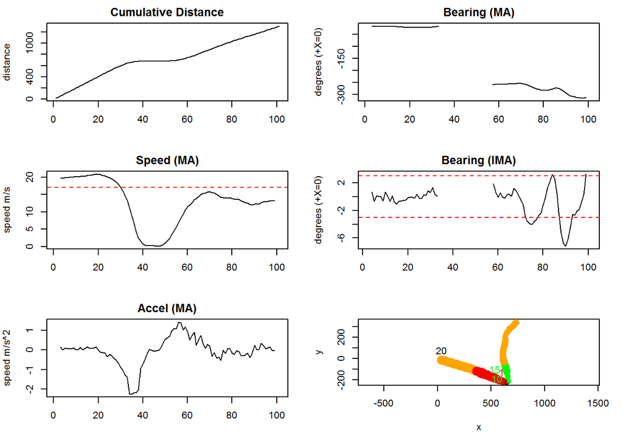

```r
plotTripSegment6(trip)
```

- Trip 6: Extremely short trip (194 secs), doesn’t meet 30 sec criteria
- Trip 16: ‘straight’ segment is 29 secs (1 under the threshold)
- Trip 40: Too short 181 secs
- Trip 45… : yada yada yada

This is starting to get redundant, so let’s look at all the trips in sorted order (lowest trip time) in order to see what these contain that we could use.

```r
asc <- order(seg.summary$trip.len)
print(seg.summary[asc, 1:7])
```

```
##     n.seg trip.len  speed.avg speed.max seg.min seg.max   seg.avg
## 157     0      156  2.9661866 12.520783      NA      NA        NA
## 147     0      163  5.3472746 13.678085      NA      NA        NA
## 71      1      165  5.0375158 16.082288      32      32  32.00000
## 100     1      169  5.7485613 17.394827      34      34  34.00000
## 85      1      171  4.4758773 18.587361      33      33  33.00000
## 103     1      173  7.5556972 18.886238      47      47  47.00000
## 115     0      175  5.0724752 15.907860      NA      NA        NA
## 152     0      178  7.1735483 19.039433      NA      NA        NA
## 40      0      181  4.9553551 15.941142      NA      NA        NA
## 104     0      183  4.6543946 15.565667      NA      NA        NA
## 41      2      189  5.8864561 13.514807      33      41  37.00000
## 154     0      191  5.1425798 14.831386      NA      NA        NA
## 185     1      191  7.5882871 18.333030      30      30  30.00000
## 173     1      193  4.8915022 14.534442      36      36  36.00000
```

[output cut: 186 more lines]

### trip 157 (2.5 mins)

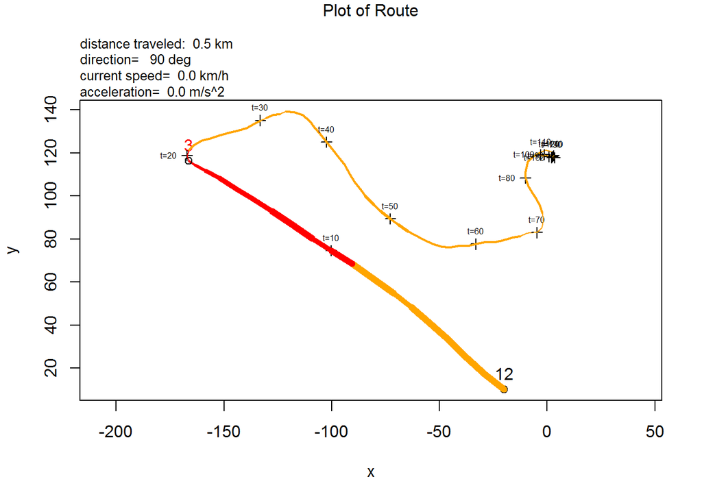

```r
trip.id <- 157
trip <- getTrip( driver.id, trip.id, v.thresh=1 )  # added v.thresh to allow for lower speed heading capture
plotTrip(trip, t.mark=10)
```

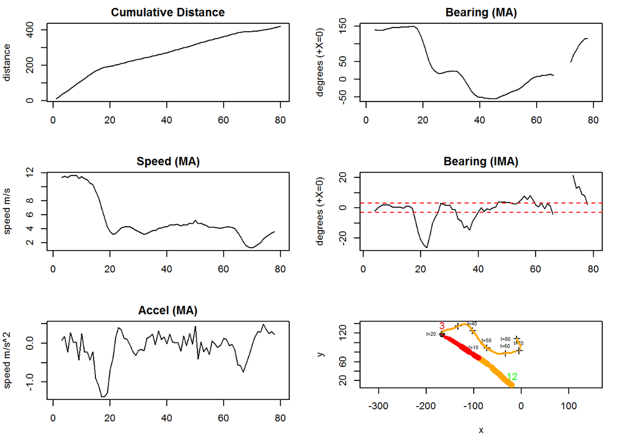

```r
plotTripSegment6(trip, 1, 80, t.mark=10)
```

Looking at this trip, and several like it, I’ve determined we need to just capture acceleration or braking segments, since almost all trips will have those. To start, I just look for deceleration and acceleration sequence by looking for sequential decreasing or increasing speeds respectively, where the speed differential is > 5 m/s (NOTE: I used these to improve the red/green acceleration coloring on the trip plots).

Let’s stop here, and start moving on to trip profiles in Part4